# Vote Dilution: Malapportionment and the First Gingles Precondition

Two legal tests, run on the census blocks of one Georgia county

Democracy’s Data

Last updated September 13, 2026 at 10:53a EDT

A district map can make your vote worth less than your neighbour’s while nobody stops you from casting it. American law calls that **vote dilution**, and it recognises two kinds. Districts of unequal population — **malapportionment**, in the law’s word — dilute everyone living in the large ones: twice the people, one representative each, half a representative apiece. Districts drawn so that a minority group can never elect anyone dilute that group instead.

So when does a map cross either line, and how does a court decide? One answer is arithmetic you could do in a spreadsheet. The other asks a plaintiff to prove something about a district that has never existed, which means somebody has to build it first.

## The test

Four files describe Houston County, Georgia, and the map its Board of Education runs on. The population counts are the 2020 census at block level, from the redistricting file that a 1975 statute, Public Law 94-171, obliges the Census Bureau to hand every state legislature so it can draw districts.[^1] The shapes are the Bureau’s 2020 TIGER/Line files, its published digital outlines of every block. The enacted five-district plan is law, passed by the Georgia General Assembly and in force. And the registered-voter counts come from Georgia’s statewide voter registration file, which records each voter’s **self-reported** race, the box the voter ticked when registering. That column exists because Section 5 of the Voting Rights Act once obliged the state to show what a change in its election rules did to minority voters.[^2]

Those four are the right files because the first *Gingles* precondition asks about a map that does not exist. Answering it needs a building block small enough to reassemble into any map at all, and the census block is that. They also supply three counts of “the people” at once, which almost nowhere else does, because almost nowhere else records race on the registration form.

The four meet on one column: `GEOID20`, the census block’s fifteen-character identifier. Every join carries the assumptions of both files plus one more about how they line up. That is the subject of Join Keys and Crosswalks, a crosswalk being a table that translates one set of areas into another. Here the join is checked rather than trusted: the four block lists were compared and match exactly, and the population the TIGER file carries for each block equals the published tables to the person.

One disclosure belongs here. Houston County’s method of electing its Board of Commissioners is the subject of pending litigation, *Driver v. Houston County*, No. 5:25-cv-00025 (M.D. Ga.), in which the instructor has been retained by plaintiffs.[^3] **No material from any expert report is used anywhere in this brief**, and nothing here reaches a legal conclusion.

## The data

One row is a 2020 census block, the smallest unit the census publishes. There are 3,269.

| Census block | Enacted district | Population | Voting age | Black adults | Registered | Black registered |
| --- | --- | --- | --- | --- | --- | --- |
| 131530211162000 | 4 | 959 | 677 | 413 | 228 | 141 |

`GEOID20` names the block and `boe5` says which of the five enacted districts it sits in. Then `pop`, `vap` and `reg` count its residents, its adults and its registered voters, each with a `_black` companion. Three counts of the people, and they are not the same number: the county is 34.54% Black by population, 32.43% among adults, and 35.56% among registered voters. That spread is 3.13 points wide, and it will decide a question the Supreme Court calls dispositive, meaning the one that settles the case.

The enacted plan arrives as a **block equivalency file**: one row per block, one district number, no boundary and no coordinate anywhere in it. A districting plan *is* a lookup table, and the picture everyone argues about is drawn afterwards by merging blocks that share a number.

Three cleaning decisions were made and none was collapsed away afterwards. “Black” means **any-part Black**, alone or in combination, matching Voting Rights Act practice. The registration counts use reported race only: voters whose race the file had inferred rather than recorded are left out. And blocks with nobody living on them are kept, 875 of the 3,269, because a district has to be drawn across empty ground.

Two things are in none of the four files. Which block touches which is worked out from the block outlines. And **most of the districts in this brief did not exist until this brief’s own code made them**, which is what evidence for the first precondition always is.

> **Before you read on, write two numbers down.** The county is 32.43% Black among adults and holds 3.24 times the Black adults a majority-Black district would need. Ignoring geography entirely gets you to 67.1%.

> First: **the highest Black share a *contiguous* district of 32,727 people can reach.** Second: **how compact that district will be**, on a scale where a perfect circle is 1 and a spidery tendril is near 0.

## What it says about democracy

### The dilution you can settle by subtraction

Add up the population of each of the enacted plan’s five districts and compare it to the average. That average, the county’s population divided by five, is the **ideal population** of 32,727, and a district’s **deviation** is how far above or below it the district sits, as a percentage of the ideal. District 3 is the largest at 33,090 people, which is 363 over the ideal, or +1.11%. District 4 is the smallest at 32,550, or -0.54%. The distance between those two, 1.65 points, is the plan’s **maximum deviation**, and it is the number a court asks for.

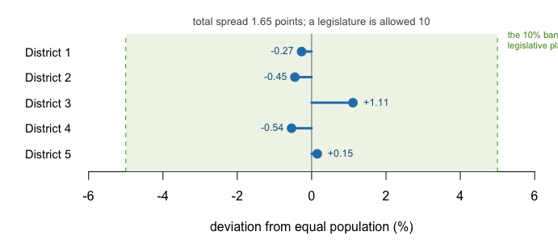

Total spread 1.65 points; the shaded band is the 10 points a legislature drawing state or local districts is presumed to be within.

**Figure 1. The enacted plan against equal population.** One bar per Board of Education district, running left or right of the ideal of 32,727 people. Bars from a zero line fit this question, because the question is distance from a single number in two directions. The shaded band is the 10-point maximum deviation a state or local plan is presumed to be within.

*Reynolds v. Sims*, 377 U.S. 533 (1964) required that legislative districts hold substantially equal populations,[^4] and *Brown v. Thomson*, 462 U.S. 835, 842 (1983) collected the rule that a state or local plan under a **10%** maximum deviation is a minor one and does not by itself make a case.[^5] This plan spans 1.65 points, a sixth of that allowance. Read as a price, a vote in the smallest district is worth 1.66% more than a vote in the largest, because one seat is shared among 32,550 people there and 33,090 here. That is the entire malapportionment inquiry, done in one subtraction.

If it is that easy, what was the rule for? Until 1963 Georgia nominated statewide officers under the **county unit system**, in which counties cast two to six unit votes each regardless of size.[^6] *Gray v. Sanders*, 372 U.S. 368, 381 (1963) struck it down, and gave the rule its name: political equality “can mean only one thing — one person, one vote.”[^7]

| Quantity | Value |
| --- | --- |
| People per unit vote, largest county | 177,785 |
| People per unit vote, smallest county | 780 |
| Ratio between them | 228 to 1 |
| Counties that together hold a unit-vote majority | 103 of 159 |
| Share of Georgians living in them | 15.3% |

**A vote in the smallest county was worth 228 votes in the largest**, and 15.3% of Georgians could outvote the rest. The equal-population rule worked so completely that it stopped being where the argument is.

### The dilution you cannot settle by subtraction

The argument moved to the other kind. Section 2 of the Voting Rights Act, 52 U.S.C. § 10301(b), makes out a violation where a group has “less opportunity than other members of the electorate to participate in the political process and to elect representatives of their choice.”[^8] *Thornburg v. Gingles*, 478 U.S. 30, 50–51 (1986) turned that into three things a plaintiff must show first, now called the **Gingles preconditions**.[^9] The group must be large enough and geographically compact enough to be a majority in one district; it must vote cohesively, meaning largely for the same candidates; and the majority must vote as a bloc against it, so that the group’s candidates usually lose.

Preconditions two and three are claims about elections that happened. **Precondition one is a claim about a district that did not**, and it is the only one a census file can answer.

Its arithmetic half is quickly done. Each of five districts holds 24,424 voting-age people, so a bare majority takes 12,212 Black adults, and the county has 39,605. “Sufficiently large” is satisfied 3.24 times over. The other half, which *Gingles* called “geographically compact,” is a fact about where those adults live.

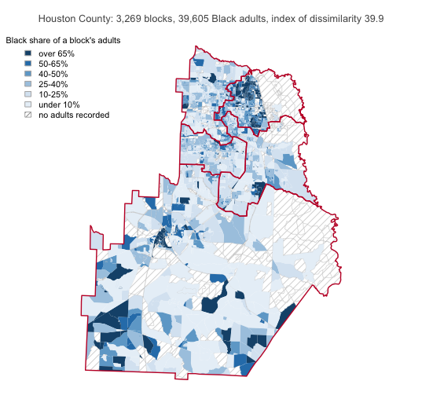

All 3,269 census blocks, shaded by the Black share of their voting-age population; the 875 hatched blocks contain nobody at all. Red lines are the five enacted districts. The county’s index of dissimilarity is 39.9.

**Figure 2. Where the Black adults are.** All 3,269 census blocks, shaded by the Black share of their voting-age population, with the five enacted districts in red. The 875 hatched blocks contain nobody at all, which is the absence of the quantity rather than a low value of it.

There is no single Black neighbourhood to enclose. The **index of dissimilarity**, meaning the share of Black adults who would have to move blocks for the two groups to be spread identically, is 39.9.[^10] Only 306 of 3,269 blocks are majority-Black among adults, holding 36.4% of the county’s Black adults, so the other 63.6% live where they are outnumbered.

So build the district and find out. Start at the block with the most Black adults and annex neighbours until the district holds 32,727 people. At each step the mapmaker looks at the **`reach`** nearest available blocks on the frontier, the blocks touching the district so far, and takes whichever leaves the Black share of adults highest. At `reach = 1` one candidate is ever considered, so race never enters the rule for growing the district; at `reach = ∞` every frontier block is a candidate.

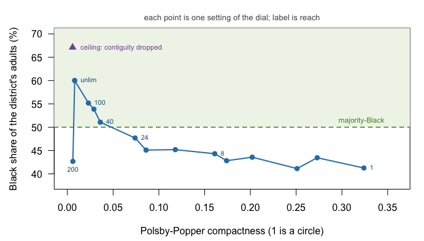

Each point is one setting of the dial. Hover for the district it produced.

**Figure 3. What the dial buys, and what it costs.** Each point is one setting of `reach`, plotted by the compactness of the district it produced and the Black share of that district’s adults. **Polsby-Popper** is the area-to-perimeter score: 1 for a circle, near zero for a long ragged edge. The triangle is the ceiling reached by dropping contiguity altogether.

The dial buys Black share and pays in compactness, at a brutal rate. At `reach = 1` the district is 41.3% Black among adults with a Polsby-Popper of 0.324: a respectable shape, nowhere near a majority. The first setting that clears 50% is reach 40, and its compactness is 9 times worse. At the far end the district reaches 60.0% at 0.008, which is not a shape so much as a route.

Two points deserve their own story. One setting is out of order: at reach 2 the district drops to 41.1%, below several tighter settings, because a greedy search, one that takes the best-looking next step without looking further ahead, is not guaranteed to improve as its own parameter grows. And the starting block barely matters, since restarting from each of 306 majority-Black blocks moves the answer only 2.1 points.

The honest summary an expert could write from Figure 3 is that a majority-Black district can be built here only by abandoning compactness. That summary is wrong.

### The map already exists

The enacted plan has been in force this whole time. Put its District 4 on the same two axes.

| District | Black of adults | Polsby popper | Reock |
| --- | --- | --- | --- |
| Algorithm, reach 1 | 41.3% | 0.324 | 0.766 |
| Algorithm, reach 40 | 51.1% | 0.036 | 0.336 |
| Algorithm, reach unlimited | 60.0% | 0.008 | 0.284 |
| Ceiling (contiguity dropped) | 67.1% | 0.006 | 0.056 |
| ENACTED District 4 | 53.7% | 0.266 | 0.514 |

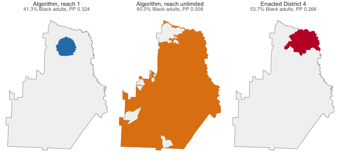

People drew that one, out of the whole county rather than outward from a seed. **Exhibiting a map settles the first precondition for good; failing to find one settles nothing**, because no search is ever exhaustive. That asymmetry, rather than the arithmetic, is what the fighting in these cases is about.

### Majority of what?

*Bartlett v. Strickland*, 556 U.S. 1, 19–20 (2009) reads the precondition to require a real numerical majority, greater than 50 percent of voting-age population.[^11] District 4 clears 50% on all three counts. Take the four-district configuration, where it does not.

[output not shown]

Neither number is wrong, and the disagreement is a join. The census counts everybody who lives here; the registration file counts everybody who signed up to vote. The bottom number everything is divided by therefore comes from a different office, on a different date, under a different rule about who counts.

## What this brief cannot tell you

**Whether anyone’s vote is actually diluted.** Precondition one is a threshold, not a verdict. Nothing above touches preconditions two and three, or the totality of the circumstances, which is nine mostly historical factors from the Senate report of 1982.

**Whether a lawful plan containing such a district exists.** The search grows one district and stops. A demonstration plan has to assign every block and keep all five districts inside the population band at once.

**Whether any of these districts would perform.** No election result appears in these four files, so bloc voting cannot be measured here.

**And the compactness scores are not facts about fairness.** Both measures used here are outline-based, so they are one limitation rather than two independent checks. A district bounded by a winding river scores badly for reasons nobody chose.

## What you should have learned

- Malapportionment is settled by subtraction: this plan spans 1.65 points against a 10-point allowance, so a vote in its smallest district is worth 1.66% more than one in its largest.
- The rule that made that easy replaced something extreme. Under Georgia’s county unit system a vote in the smallest county was worth 228 votes in the largest, and 15.3% of the state could outvote the rest.
- The first *Gingles* precondition has two halves and only one is arithmetic. This county holds 3.24 times the Black adults a majority district needs, and is still spread out, at an index of dissimilarity of 39.9.
- Compactness and minority share trade along a curve, from 41.3% Black at Polsby-Popper 0.324 to 60.0% at 0.008 — and the enacted District 4 sits off it, at 53.7% and 0.266. The curve described a search, not a county.
- “Majority” needs a bottom number. In the four-district configuration every district is majority-Black among registered voters and none is among adults, because the two counts come from two files with different rules about who counts.

## Extensions

None of these is answered above, and every one can be answered from the tables the Sources section hands over.

- `districts.csv` carries `pop_black_pct`, `vap_black_pct` and `reg_black_pct` for the same districts. Sort by each in turn. Does the ranking of the five enacted districts change with the choice?
- `tradeoff.csv` has `reach`, `vap_black_pct`, `pp` and `reock`. Sort the two compactness columns against each other. Do they agree about which districts are worst shaped?
- `seed_sweep.csv` grows a district from many starting blocks. Compare the spread of `d5_vap_black_pct` with the spread of `d5_reg_black_pct`. Does the starting block matter more for one population base than the other?
- `ga_county_units.csv` gives `people_per_unit` for every Georgia county under the old rule. Sort it, then find how few counties it takes to reach a majority of `units`.
- **Stretch.** Find your own county’s block-equivalency file for a local board and compute its population deviation from the census block counts. Is it inside the 10-point band?
- **Stretch.** `blocks.csv` has `x_km` and `y_km` for every block. Work out how far apart the Blackest blocks sit, and compare that with the width of a district holding 32,727 people.

## Sources

**Data**

- 2020 Census, P.L. 94-171 redistricting file, block level, Houston County, Georgia: population and voting-age population, both by race. https://www2.census.gov/programs-surveys/decennial/2020/data/01-Redistricting_File--PL_94-171/Georgia/ga2020.pl.zip
- 2020 TIGER/Line tabulation blocks for Georgia, the Bureau’s digital block outlines, used for geometry, adjacency and both compactness measures. Its independent `POP20` field agrees with the tables above at 163,633 people. https://www2.census.gov/geo/tiger/TIGER2020/TABBLOCK20/tl_2020_13_tabblock20.zip
- Houston County Board of Education plan, as enacted and in force, as a block-equivalency file.
- Georgia’s statewide voter registration file, kept by the Secretary of State and available to the public, restricted here to Houston County: 49,771 records, each with the voter’s **self-reported** race and census block. Voters whose race the file had inferred rather than recorded are not counted.
- Every district here other than the enacted five was drawn by the growth algorithm described above.

**The data itself**

Every figure above is drawn from these tables. They are plain CSV, they open in a spreadsheet, and they are yours to take further.

`adjacency.csv`, `block_shapes.csv`, `blocks.csv`, `districts.csv`, `ga_county_units.csv`, `plan_shapes.csv`, `seed_sweep.csv`, `segregation.csv`, `tradeoff.csv`

**Cases and statute**

- Voting Rights Act of 1965 § 2, 52 U.S.C. § 10301 (results test added 1982, Pub. L. 97-205 § 3, 96 Stat. 134), https://www.law.cornell.edu/uscode/text/52/10301; § 5, 52 U.S.C. § 10304, https://www.law.cornell.edu/uscode/text/52/10304, whose coverage formula *Shelby County v. Holder*, 570 U.S. 529 (2013) struck, https://www.law.cornell.edu/supremecourt/text/12-96.
- Senate Report No. 97-417 (1982), whose nine factors *Gingles* adopted.
- *Gray v. Sanders*, 372 U.S. 368 (1963), https://www.law.cornell.edu/supremecourt/text/372/368; *Reynolds v. Sims*, 377 U.S. 533 (1964), https://www.law.cornell.edu/supremecourt/text/377/533; *Brown v. Thomson*, 462 U.S. 835 (1983), https://www.law.cornell.edu/supremecourt/text/462/835.
- *Thornburg v. Gingles*, 478 U.S. 30 (1986), https://www.law.cornell.edu/supremecourt/text/478/30; *Bartlett v. Strickland*, 556 U.S. 1 (2009) (plurality), https://www.law.cornell.edu/supremecourt/text/07-689; *Allen v. Milligan*, 599 U.S. 1 (2023), https://www.supremecourt.gov/opinions/22pdf/21-1086_1co6.pdf; *Louisiana v. Callais*, 608 U.S. ___ (2026) (Nos. 24-109, 24-110), https://www.supremecourt.gov/opinions/25pdf/24-109_new_jifl.pdf.

**Academic literature**

- Duncan, O. D. and Duncan, B. (1955). “A Methodological Analysis of Segregation Indexes.” *American Sociological Review* 20(2): 210–217. https://www.jstor.org/stable/2088328. The index of dissimilarity.
- National Conference of State Legislatures. *Redistricting Law 2020*. Denver: NCSL, October 2019, chapter 3, for the nine totality factors. https://www.ncsl.org/redistricting-and-census/redistricting-law-2020
- Polsby, D. D. and Popper, R. D. (1991). “The Third Criterion: Compactness as a Procedural Safeguard Against Partisan Gerrymandering.” *Yale Law & Policy Review* 9(2): 301–353.
- Reock, E. C. Jr. (1961). “A Note: Measuring Compactness as a Requirement of Legislative Apportionment.” *Midwest Journal of Political Science* 5(1): 70–74. https://www.jstor.org/stable/2109043
[^1]: The Census Bureau’s page on the P.L. 94-171 redistricting data: https://www.census.gov/programs-surveys/decennial-census/about/rdo/summary-files.html.
[^2]: The Department of Justice’s description of Section 5 and the preclearance it required until 2013: https://www.justice.gov/crt/about-section-5-voting-rights-act.
[^3]: The docket is public. Filings are indexed by CourtListener, a free archive of federal court records: https://www.courtlistener.com/?q=%22Driver+v.+Houston+County%22.
[^4]: *Reynolds v. Sims*, 377 U.S. 533 (1964): https://www.law.cornell.edu/supremecourt/text/377/533.
[^5]: *Brown v. Thomson*, 462 U.S. 835 (1983): https://www.law.cornell.edu/supremecourt/text/462/835.
[^6]: The New Georgia Encyclopedia’s account of the county unit system: https://www.georgiaencyclopedia.org/articles/government-politics/county-unit-system/.
[^7]: *Gray v. Sanders*, 372 U.S. 368 (1963): https://www.law.cornell.edu/supremecourt/text/372/368.
[^8]: 52 U.S.C. § 10301: https://www.law.cornell.edu/uscode/text/52/10301.
[^9]: *Thornburg v. Gingles*, 478 U.S. 30 (1986): https://www.law.cornell.edu/supremecourt/text/478/30.
[^10]: The index is from Otis Dudley Duncan and Beverly Duncan, “A Methodological Analysis of Segregation Indexes,” *American Sociological Review* 20, no. 2 (1955): 210–217, https://www.jstor.org/stable/2088328.
[^11]: *Bartlett v. Strickland*, 556 U.S. 1 (2009): https://www.law.cornell.edu/supremecourt/text/07-689.
[^12]: *Louisiana v. Callais*, No. 24-109, slip opinion of 29 April 2026: https://www.supremecourt.gov/opinions/25pdf/24-109_new_jifl.pdf. The docket is at https://www.supremecourt.gov/search.aspx?filename=/docket/docketfiles/html/public/24-109.html.